# Power Comparison for Simulation Based on HDST

Jiaqiang Zhu

March 13th, 2020

Three Patterns Examined for Power Comparison

> Figure 0: Three Patterns (A): Layer E (B): Layer ONL (C): Layer GL

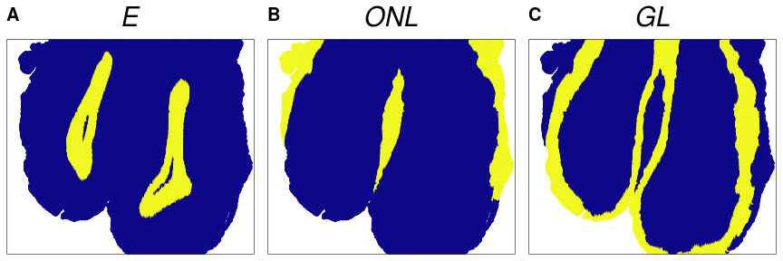

Pattern Plots

**Power Figures (Fig.1-4): numZero = 1000, sigZero = 200.**  
In this setting, KDC does not fare well in the Layer E (A) across all sample size. For the second pattern (B), the power trend is not clear: high in 20X resolution, but decrease at 15X resolution, and then bounce back at 10X resolution. For the third pattern (C), KDC reaches highest power at 15X resolution, and **spatialDE** maximum power is at 20X resolution. **SPARK** result is very stable across all setting.

> Figure 1: 25X, numZero = 1000, sigZero = 200

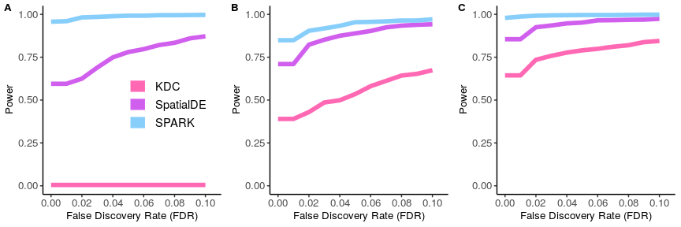

25X Power Comparison

> Figure 2: 20X, numZero = 1000, sigZero = 200

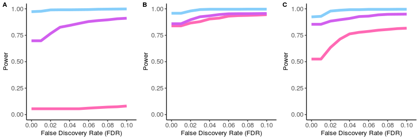

20X Power Comparison

> Figure 3: 15X, numZero = 1000, sigZero = 200

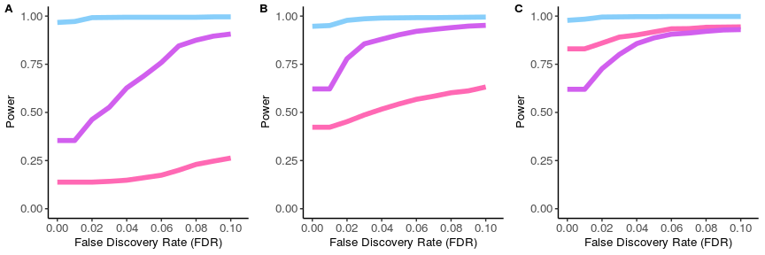

15X Power Comparison

> Figure 4: 10X, numZero = 1000, sigZero = 200

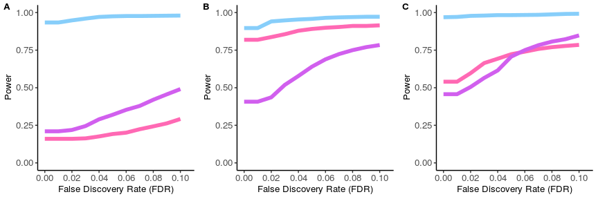

10X Power Comparison

**Power Figures II (Fig.5-8), numZero = 500, sigZero = 100.**  
In this setting, KDC gains power in the Layer E (A) as the sample size increases. For the other two patterns (B) and (C), KDC attains high power.  
Both **SPARK** and **SpatialDE** attains full power in almost all setting. Though the ratio of numZero/sigZero are the same between these two settings, the 500/100 version probably has less noise.

> Figure 5: 25X, numZero = 500, sigZero = 100

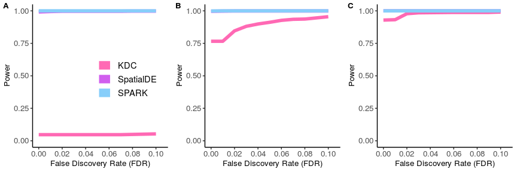

25X Power Comparison

> Figure 6: 20X, numZero = 500, sigZero = 100

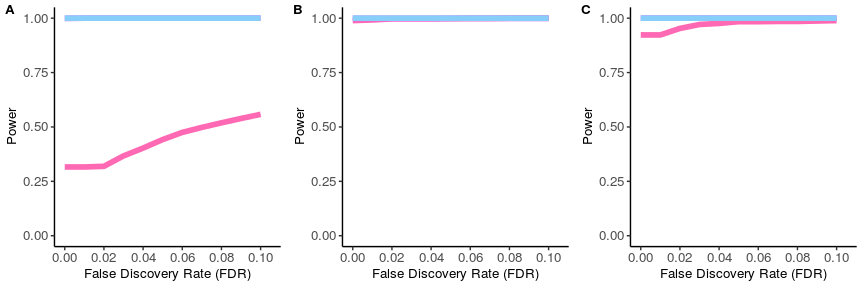

20X Power Comparison

> Figure 7: 15X, numZero = 500, sigZero = 100

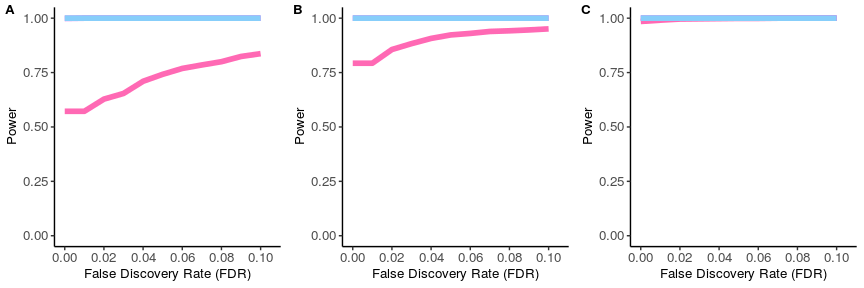

15X Power Comparison

> Figure 8: 10X, numZero = 500, sigZero = 100

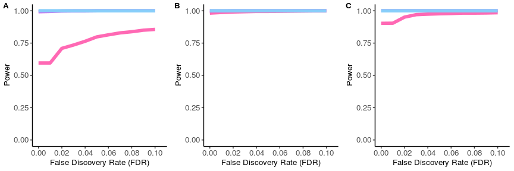

10X Power Comparison

> Figure 9: 25X, numZero = 2000, sigZero = 200

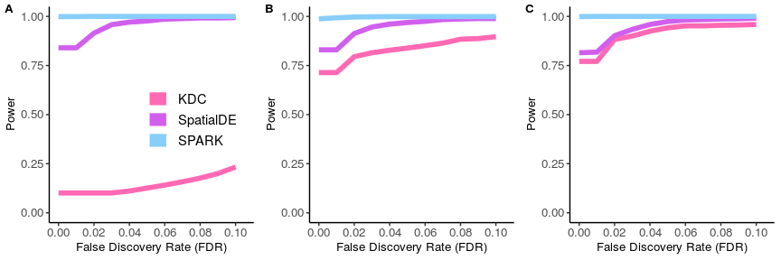

25X Power Comparison

> Figure 10: 20X, numZero = 2000, sigZero = 200

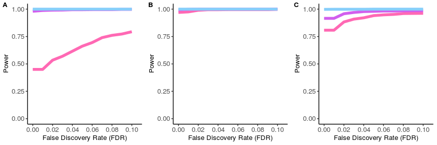

20X Power Comparison

> Figure 11: 15X, numZero = 2000, sigZero = 200

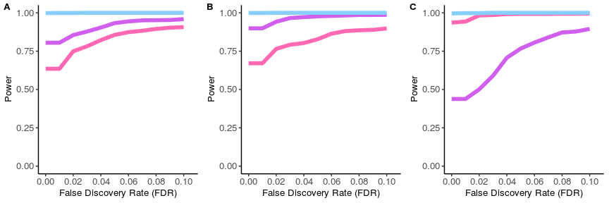

15X Power Comparison

> Figure 12: 10X, numZero = 2000, sigZero = 200

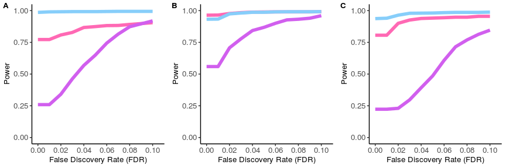

10X Power Comparison

> Figure 13: 5X, numZero = 2000, sigZero = 200

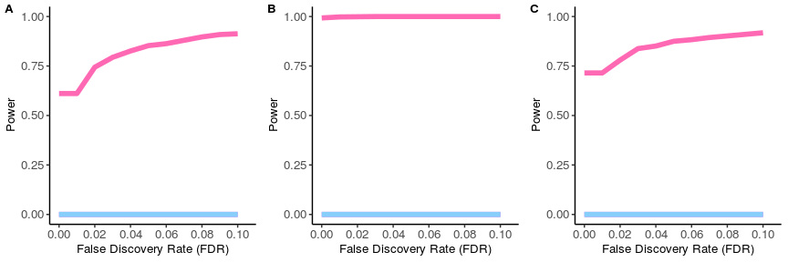

5X Power Comparison